# Forecasting Electricity Demand

A worked case study in time-series forecasting, with a real generation-mix leakage trap

Author

Your Name

Published

October 16, 2026

**TipInteractive application**

[Open the Streamlit app](https://energy-demand-forecasting.streamlit.app)

## 1 Introduction

I built this project to predict hourly electricity demand (`Consumption`, megawatts) for Romania’s national grid, using real, published data from 2019 onward, together with its generation mix (nuclear, wind, hydro, oil & gas, coal, solar, biomass). I picked demand forecasting as a deliberately different kind of project for this portfolio: every other project treats each row as independent, while this one is a **time series**, where the order of the rows *is* the problem and a shuffled train/test split would quietly leak.

I originally built this project on US grid data (PJM Interconnection), then switched to this Romanian dataset specifically because the generation-mix breakdown is genuinely useful, interesting data the US version didn’t have — it lets me ask whether recent generation mix carries any forecasting signal, and it comes with its own real energy-transition story.

One thing worth flagging upfront: **this dataset is live and continuously updated** — checked directly, an earlier download had 46,002 rows through April 2024, the version used here has 62,810 rows through March 2026, with older rows unchanged. Every number below reflects one snapshot, not a fixed, versioned file.

I still couldn’t find a real, public, hourly demand dataset for Vietnam’s own grid. Romania is a different climate and market structure, but grid-scale demand forecasting is the same *kind* of problem regardless of country, and Romania’s growing renewable share raises questions increasingly relevant to Vietnam’s own energy transition too.

## 2 Data

```python
from energy_demand_forecasting import config, data

df = data.load_raw()
print(f"{len(df)} rows, {df[config.DATETIME_COL].min()} to {df[config.DATETIME_COL].max()}")
```

```
62810 rows, 2019-01-01 00:00:00 to 2026-03-14 23:00:00
```

### 2.1 Three real data-quality issues — and they are not the same issue

```python
dupes = df[df[config.DATETIME_COL].duplicated(keep=False)]
full_range = pd.date_range(df[config.DATETIME_COL].min(), df[config.DATETIME_COL].max(), freq="h")
missing = full_range.difference(df[config.DATETIME_COL])
n_extra = df[config.DATETIME_COL].duplicated().sum()
print(f"{dupes[config.DATETIME_COL].nunique()} timestamps appear more than once "
      f"({len(dupes)} rows, i.e. {n_extra} extra copies); {len(missing)} missing timestamps")

gaps = data.gap_lengths(df)
print(f"{len(gaps)} separate gaps, longest: {gaps.max()} hours")
```

```
7 timestamps appear more than once (18 rows, i.e. 11 extra copies); 321 missing timestamps
78 separate gaps, longest: 83 hours
```

#### 2.1.1 A third issue: fabricated readings in 2025-2026

The largest `Consumption` values in the raw file are not cold snaps. They sit in the middle of the night, climb hour after hour to 10,000-12,000 MW (the raw maximum is 11,986 MW at 06:00 on 27 November 2025), and then fall back by thousands of MW within a single hour. Checking every column at those hours shows what is going on: each row is an **exact scaled-up copy of the row before it** — `Production`, `Nuclear`, `Hydroelectric`, `Oil and Gas`, `Coal` and `Consumption` all change by the same factor, hour after hour. Real hours never do that: nuclear output is nearly constant while demand moves, and here it climbs to about 2,080 MW, well beyond what Romania’s only nuclear plant (Cernavoda, two ~700 MW units) can produce. It looks like a fault in the live feed that fills hours by rescaling the last real reading.

`data.flag_implausible_readings` (called inside `clean_frame`) removes these with a deliberately conservative, documented rule (constants in `config.py`):

1. **Trigger** — an hour is clearly impossible if `Consumption` is more than 1.5x the median of the same clock hour over the surrounding ±7 days, *or* `Nuclear` exceeds 1,500 MW. Neither ever happens in 2019-2024 (the highest ratio there is 1.46, the highest nuclear reading 1,457 MW). Unusually *low* hours are never flagged: real holidays fall below half the usual level.
2. **Extent** — the flag spreads over the contiguous run of hours that are exact proportional copies of the hour before (all six columns above changing by the same factor, within 1%), since the whole run is produced by the same fault. The genuine hour being copied is kept.

Flagged hours are set to missing in every column and interpolated like the gaps above.

```python
flagged = data.implausible_readings(df)
stretch_id = (flagged.index.to_series().diff() != pd.Timedelta(hours=1)).cumsum()
stretches = flagged.groupby(stretch_id.values).agg(
    start=("Consumption", lambda s: s.index.min()),
    end=("Consumption", lambda s: s.index.max()),
    hours=("Consumption", "size"),
    max_consumption_MW=("Consumption", "max"),
    max_ratio_to_usual=("ratio", "max"),
    max_nuclear_MW=("Nuclear", "max"),
).reset_index(drop=True)
print(f"{len(flagged)} hours flagged, in {len(stretches)} separate stretches, "
      f"all between {flagged.index.min():%Y-%m-%d} and {flagged.index.max():%Y-%m-%d}")
stretches.round(2)
```

```
123 hours flagged, in 16 separate stretches, all between 2025-03-26 and 2026-02-11
```

|  | start | end | hours | max_consumption_MW | max_ratio_to_usual | max_nuclear_MW |
| --- | --- | --- | --- | --- | --- | --- |
| 0 | 2025-03-26 23:00:00 | 2025-03-27 07:00:00 | 9 | 8735.0 | 1.48 | 1852.0 |
| 1 | 2025-04-22 08:00:00 | 2025-04-22 09:00:00 | 2 | 5607.0 | 1.01 | 1506.0 |
| 2 | 2025-04-24 08:00:00 | 2025-04-24 13:00:00 | 6 | 6561.0 | 1.43 | 1598.0 |
| 3 | 2025-04-25 17:00:00 | 2025-04-25 22:00:00 | 6 | 5743.0 | 0.97 | 1548.0 |
| 4 | 2025-04-29 17:00:00 | 2025-04-29 18:00:00 | 2 | 5479.0 | 0.96 | 1524.0 |
| 5 | 2025-05-09 07:00:00 | 2025-05-09 08:00:00 | 2 | 6137.0 | 1.05 | 1537.0 |
| 6 | 2025-05-25 19:00:00 | 2025-05-26 05:00:00 | 11 | 7631.0 | 1.51 | 910.0 |
| 7 | 2025-08-07 20:00:00 | 2025-08-08 07:00:00 | 12 | 10112.0 | 1.79 | 1866.0 |
| 8 | 2025-09-14 23:00:00 | 2025-09-15 05:00:00 | 7 | 6441.0 | 1.28 | 1590.0 |
| 9 | 2025-10-02 17:00:00 | 2025-10-03 05:00:00 | 13 | 10179.0 | 1.93 | 1921.0 |
| 10 | 2025-10-04 14:00:00 | 2025-10-04 19:00:00 | 6 | 7113.0 | 1.09 | 1598.0 |
| 11 | 2025-10-10 20:00:00 | 2025-10-11 06:00:00 | 11 | 10914.0 | 1.94 | 2007.0 |
| 12 | 2025-11-26 17:00:00 | 2025-11-27 06:00:00 | 14 | 11986.0 | 2.02 | 2081.0 |
| 13 | 2026-01-11 21:00:00 | 2026-01-12 05:00:00 | 9 | 9789.0 | 1.56 | 1739.0 |
| 14 | 2026-01-24 02:00:00 | 2026-01-24 10:00:00 | 9 | 8062.0 | 1.09 | 1722.0 |
| 15 | 2026-02-11 19:00:00 | 2026-02-11 22:00:00 | 4 | 9460.0 | 1.33 | 1517.0 |

The six stretches that reach 1.5x the usual level contain every one of the dataset’s 10,000-12,000 MW “peaks”; the others are milder copies of the same fault, caught because their nuclear reading is physically impossible. The complete list of flagged hours:

**NoteAll flagged hours (raw values, with the same-hour median they were judged against)**

```
                     Consumption  Production  Nuclear  same_hour_median  ratio
DateTime
2025-03-26 23:00:00       6713.0      6226.0   1426.0            6067.0   1.11
2025-03-27 00:00:00       6780.0      6288.0   1440.0            5734.5   1.18
2025-03-27 01:00:00       7254.0      6728.0   1540.0            5528.0   1.31
2025-03-27 02:00:00       7544.0      6997.0   1601.0            5434.0   1.39
2025-03-27 03:00:00       7770.0      7206.0   1649.0            5395.0   1.44
2025-03-27 04:00:00       8080.0      7494.0   1714.0            5458.0   1.48
2025-03-27 05:00:00       8241.0      7643.0   1748.0            5582.5   1.48
2025-03-27 06:00:00       8241.0      7643.0   1748.0            5945.0   1.39
2025-03-27 07:00:00       8735.0      8101.0   1852.0            6342.5   1.38
2025-04-22 08:00:00       5444.0      3627.0   1463.0            5582.5   0.98
2025-04-22 09:00:00       5607.0      3735.0   1506.0            5530.0   1.01
2025-04-24 08:00:00       5834.0      4433.0   1422.0            5309.5   1.10
2025-04-24 09:00:00       5834.0      4433.0   1422.0            5261.0   1.11
2025-04-24 10:00:00       6067.0      4610.0   1478.0            4974.5   1.22
2025-04-24 11:00:00       6249.0      4748.0   1522.0            4689.0   1.33
2025-04-24 12:00:00       6561.0      4985.0   1598.0            4586.5   1.43
2025-04-24 13:00:00       6561.0      4985.0   1598.0            4588.5   1.43
2025-04-25 17:00:00       5059.0      5146.0   1365.0            5239.5   0.97
2025-04-25 18:00:00       5059.0      5146.0   1365.0            5567.5   0.91
2025-04-25 19:00:00       5311.0      5403.0   1433.0            5932.5   0.90
2025-04-25 20:00:00       5311.0      5403.0   1433.0            6080.0   0.87
2025-04-25 21:00:00       5470.0      5565.0   1475.0            6213.0   0.88
2025-04-25 22:00:00       5743.0      5843.0   1548.0            5999.0   0.96
2025-04-29 17:00:00       5169.0      4731.0   1438.0            5401.5   0.96
2025-04-29 18:00:00       5479.0      5014.0   1524.0            5784.0   0.95
2025-05-09 07:00:00       5845.0      5856.0   1464.0            5827.5   1.00
2025-05-09 08:00:00       6137.0      6148.0   1537.0            5856.5   1.05
2025-05-25 19:00:00       5530.0      4432.0    662.0            6480.0   0.85
2025-05-25 20:00:00       5640.0      4520.0    675.0            6748.5   0.84
2025-05-25 21:00:00       5922.0      4746.0    708.0            6860.0   0.86
2025-05-25 22:00:00       6218.0      4983.0    743.0            6340.5   0.98
2025-05-25 23:00:00       6653.0      5331.0    795.0            5805.0   1.15
2025-05-26 00:00:00       6919.0      5544.0    826.0            5427.0   1.27
2025-05-26 01:00:00       6988.0      5599.0    834.0            5198.0   1.34
2025-05-26 02:00:00       7197.0      5766.0    859.0            5056.0   1.42
2025-05-26 03:00:00       7556.0      6054.0    901.0            5060.5   1.49
2025-05-26 04:00:00       7631.0      6114.0    910.0            5046.0   1.51
2025-05-26 05:00:00       7631.0      6114.0    910.0            5110.5   1.49
```

[output cut: 70 more lines]

```
2026-01-12 04:00:00       9323.0      8075.0   1657.0            6054.5   1.54
2026-01-12 05:00:00       9789.0      8478.0   1739.0            6272.0   1.56
2026-01-24 02:00:00       6316.0      5455.0   1352.0            6036.5   1.05
2026-01-24 03:00:00       6316.0      5455.0   1352.0            6040.5   1.05
2026-01-24 04:00:00       6631.0      5727.0   1419.0            6078.0   1.09
2026-01-24 05:00:00       6896.0      5956.0   1475.0            6323.0   1.09
2026-01-24 06:00:00       6896.0      5956.0   1475.0            6942.0   0.99
2026-01-24 07:00:00       7240.0      6253.0   1548.0            7732.0   0.94
2026-01-24 08:00:00       7457.0      6440.0   1594.0            8243.0   0.90
2026-01-24 09:00:00       7606.0      6568.0   1625.0            8376.5   0.91
2026-01-24 10:00:00       8062.0      6962.0   1722.0            8231.5   0.98
2026-02-11 19:00:00       8334.0      7994.0   1338.0            8295.0   1.00
2026-02-11 20:00:00       8500.0      8153.0   1364.0            8111.5   1.05
2026-02-11 21:00:00       8925.0      8560.0   1432.0            7696.5   1.16
2026-02-11 22:00:00       9460.0      9073.0   1517.0            7139.5   1.33
```

This is not a perfect fix. Interpolating a 9-14 hour overnight stretch with a straight line misses the real night-time dip, and milder copies that trip neither trigger (as well as some older stretches where the feed simply repeated one reading for several hours) are left as they are; the rule only removes values that are clearly impossible.

```python
frame = data.load_clean_frame()
print(f"{len(frame)} hours, strictly regular: {(frame.index.to_series().diff().dropna() == pd.Timedelta(hours=1)).all()}")
print(f"Peak demand after cleaning: {frame[config.TARGET_COL].max():,.0f} MW "
      f"at {frame[config.TARGET_COL].idxmax()} (raw maximum: {df[config.TARGET_COL].max():,.0f} MW)")
```

```
63120 hours, strictly regular: True
Peak demand after cleaning: 9,615 MW at 2021-01-19 10:00:00 (raw maximum: 11,986 MW)
```

### 2.2 Exploring the series and its generation mix

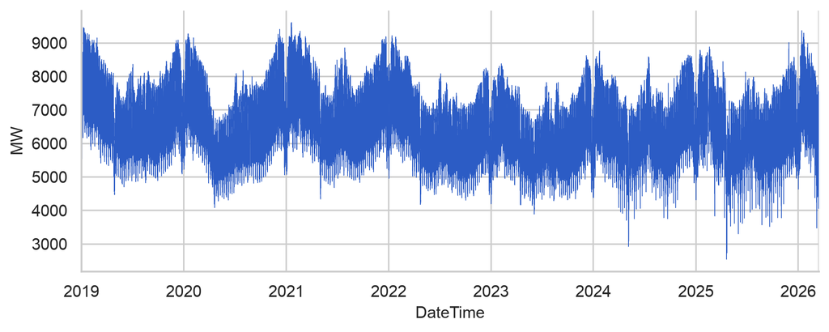

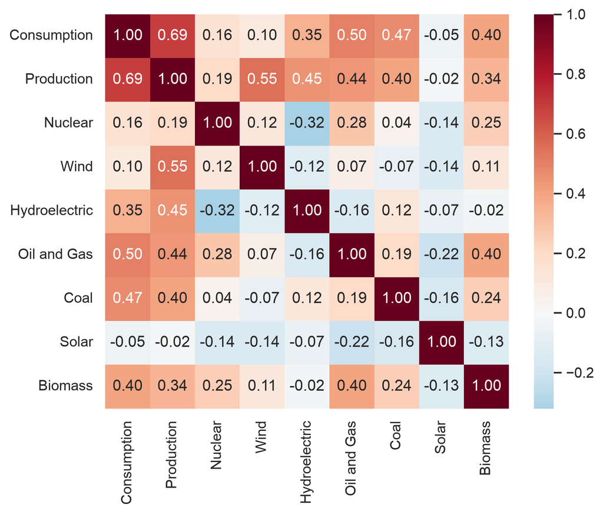

```python
fig, ax = plt.subplots(figsize=(9, 3.2))
frame[config.TARGET_COL].plot(ax=ax, linewidth=0.4, color=PALETTE[0])
ax.set_ylabel("MW")
plt.show()

corr = frame.corr()
fig, ax = plt.subplots(figsize=(7, 5.5))
sns.heatmap(corr, annot=True, fmt=".2f", cmap="RdBu_r", center=0, ax=ax)
plt.show()
```

`Consumption` correlates most with `Production` (0.69, as expected) and the two dispatchable fossil sources, `Oil and Gas` (0.50) and `Coal` (0.47) — the grid operator leans on fossil generation specifically to follow demand swings. `Solar` is essentially uncorrelated with demand (-0.05), which is exactly what I’d expect: solar output follows daylight and weather, not consumption.

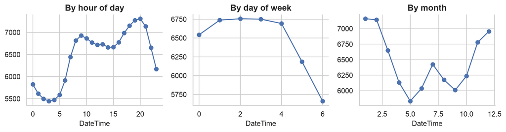

```python
fig, axes = plt.subplots(1, 3, figsize=(11, 3.0))
frame.groupby(frame.index.hour)[config.TARGET_COL].mean().plot(ax=axes[0], marker="o", title="By hour of day")
frame.groupby(frame.index.dayofweek)[config.TARGET_COL].mean().plot(ax=axes[1], marker="o", title="By day of week")
frame.groupby(frame.index.month)[config.TARGET_COL].mean().plot(ax=axes[2], marker="o", title="By month")
plt.tight_layout()
plt.show()
```

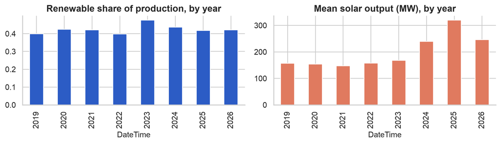

```python
renewable_share = frame[config.RENEWABLE_COLS].sum(axis=1) / frame["Production"]
fig, axes = plt.subplots(1, 2, figsize=(10, 3.0))
renewable_share.groupby(frame.index.year).mean().plot.bar(ax=axes[0], title="Renewable share of production, by year", color=PALETTE[0])
frame.groupby(frame.index.year)["Solar"].mean().plot.bar(ax=axes[1], title="Mean solar output (MW), by year", color=PALETTE[3])
plt.tight_layout()
plt.show()
```

The clearest “genuinely useful and interesting” finding from having the generation-mix breakdown at all: renewable share has held around 40-48% of production every year since 2019, but **mean solar output roughly doubled between 2023 (~168 MW) and 2025 (~320 MW)** — a real, checkable signature of Romania’s recent solar buildout.

## 3 Statistical rigor before modeling

### 3.1 Is this series stationary?

```python
from energy_demand_forecasting import model

adf_result = model.stationarity_test(frame[config.TARGET_COL])
print(f"ADF statistic: {adf_result['statistic']:.2f}, p-value: {adf_result['p_value']:.4g}")
```

```
ADF statistic: -14.06, p-value: 3.045e-26
```

Formally stationary (no unit root) — which looked wrong to me at first given the obvious daily/monthly patterns above. The resolution: ADF specifically tests for a *stochastic trend*, not for seasonality. A strong, bounded, repeating pattern always reverts toward its typical shape rather than wandering further from it, so it doesn’t have a unit root even though it clearly isn’t “flat.”

### 3.2 Autocorrelation, used to justify lag choices empirically

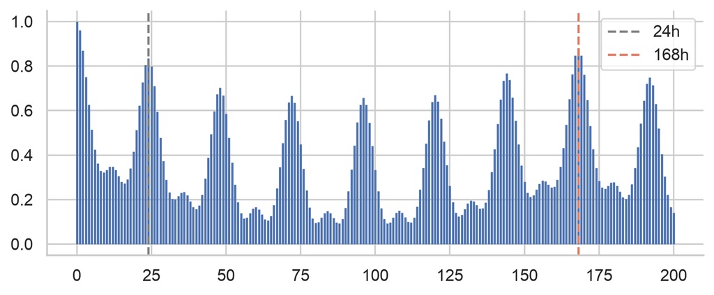

```
ACF at lag 1h: 0.9618
ACF at lag 24h: 0.8347
ACF at lag 48h: 0.7026
ACF at lag 168h: 0.8813
```

```python
acf_values = model.autocorrelation(frame[config.TARGET_COL], n_lags=200)
fig, ax = plt.subplots(figsize=(8, 3.0))
ax.stem(range(len(acf_values)), acf_values, markerfmt=" ", basefmt=" ")
ax.axvline(24, linestyle="--", color="gray", label="24h")
ax.axvline(168, linestyle="--", color=PALETTE[3], label="168h")
ax.legend()
plt.show()
for lag in [1, 24, 48, 168]:
    print(f"ACF at lag {lag}h: {acf_values[lag]:.4f}")
```

Autocorrelation is genuinely high at both 24h (0.83) and 168h (0.88 — if anything slightly stronger), with a noticeably weaker mid-point at 48h (0.70) — empirical justification for these two specific lags, rather than picking them by convention.

## 4 Feature engineering

### 4.1 The leakage trap in the generation-mix columns

`Production` and its 7 source breakdowns are recorded at the **same hour** as `Consumption`, not before it. Using them directly would be circular for a real forecasting task, since generation is dispatched in response to demand, not fixed in advance. Every generation-mix feature is lagged by 24 hours.

```python
from energy_demand_forecasting import features

seasonal_lookup = features.fit_seasonal_lookup(frame[config.TARGET_COL].iloc[: int(len(frame) * 0.85)])
X, y = features.split_features_target(frame, seasonal_lookup=seasonal_lookup)
X[["lag_24h", "lag_168h", "Solar_lag_24h", "net_export_lag_24h", "renewable_share_lag_24h"]].tail(3)
```

| DateTime | lag_24h | lag_168h | Solar_lag_24h | net_export_lag_24h | renewable_share_lag_24h |
| --- | --- | --- | --- | --- | --- |
| 2026-03-14 21:00:00 | 7041.0 | 6402.0 | 0.0 | -185.0 | 0.441219 |
| 2026-03-14 22:00:00 | 6426.0 | 6234.0 | 0.0 | 115.0 | 0.415839 |
| 2026-03-14 23:00:00 | 6019.0 | 5777.0 | 0.0 | 348.0 | 0.394220 |

### 4.2 A leakage-safe way to reuse a seasonal-decomposition idea

A natural next step is decomposing the series into trend/seasonal/ residual components and adding them as features. Doing this the most direct way — fitting `statsmodels`’ decomposition on the whole series before splitting — leaks: the trend component is a **centered** moving average using points both before *and after* each timestamp, so fitting it on the full series means training features are quietly built with future test-period information. `fit_seasonal_lookup` fits the decomposition **only on the training split** and reuses just the strictly periodic seasonal component (24 fixed hour-of-day offsets, safe to reapply to any timestamp without recomputation).

```python
X_train, X_test, y_train, y_test = model.chronological_train_test_split(X, y)
pipe_with = model.build_pipeline(model.lightgbm_estimator())
pipe_with.fit(X_train, y_train)
scores_with = model.regression_scores(y_test, pipe_with.predict(X_test))

X_without, y_without = features.split_features_target(frame)
X_train_wo, X_test_wo, y_train_wo, y_test_wo = model.chronological_train_test_split(X_without, y_without)
pipe_without = model.build_pipeline(model.lightgbm_estimator())
pipe_without.fit(X_train_wo, y_train_wo)
scores_without = model.regression_scores(y_test_wo, pipe_without.predict(X_test_wo))

print("WITH seasonal_24h:   ", {k: round(v, 4) for k, v in scores_with.items()})
print("WITHOUT seasonal_24h:", {k: round(v, 4) for k, v in scores_without.items()})
```

```
WITH seasonal_24h:    {'mae': 239.7615, 'rmse': 341.1845, 'mape': 0.0405}
WITHOUT seasonal_24h: {'mae': 239.278, 'rmse': 342.4446, 'mape': 0.0405}
```

An honest negative result: adding the seasonal-decomposition feature makes essentially no difference (identical MAPE to 4 decimal places). LightGBM’s tree splits likely already extract everything useful from the cyclical `hour_sin`/`hour_cos` encoding plus the lag/rolling features — worth reporting the idea that didn’t help, not only the ones that did.

## 5 Methodology

### 5.1 Why the train/test split is chronological, not shuffled

Lag and rolling-window features are built from each row’s own recent past, so a random shuffle would leak near-future information into training rows sitting next to shuffled-in test rows. The split is by position along the time-sorted index (last 15% of hours as test), and cross-validation uses `TimeSeriesSplit`, never `KFold` — run on the **training period only**, so cross-validation and the final test are two independent measurements.

### 5.2 Two baselines, measured before trusting any model

What each model is actually asked to do matters here. Scored on `X_test`, every model makes a **1-hour-ahead** forecast: its `rolling_*_24h` features already include the hour just before the one being predicted. The honest no-model bar for that job is **persistence** — “demand will be what it was an hour ago”. The “same hour last week” **seasonal naive** baseline is the fair bar for forecasts further ahead, where the previous hour isn’t known yet.

```python
baselines = pd.DataFrame({
    "Persistence (previous hour)": model.persistence_baseline(frame, y_test_wo),
    "Seasonal naive (same hour last week)": model.naive_seasonal_baseline(X_test_wo, y_test_wo),
}).T
baseline_scores = baselines.loc["Seasonal naive (same hour last week)"]
persistence_scores = baselines.loc["Persistence (previous hour)"]
baselines.round(4)
```

|  | mae | rmse | mape |
| --- | --- | --- | --- |
| Persistence (previous hour) | 244.4572 | 313.8748 | 0.0394 |
| Seasonal naive (same hour last week) | 442.9998 | 645.5151 | 0.0744 |

On the test period, “same hour last week” is off by **7.4%** on average (MAPE), but simply repeating the previous hour is off by only **3.9%**. Persistence is the bar the 1-hour-ahead models have to clear.

### 5.3 Model comparison, via TimeSeriesSplit on the training period

```python
X_train_cv, y_train_cv = X_train_wo, y_train_wo
for i, (tr, va) in enumerate(model.time_series_folds(X_train_cv, cv=5), start=1):
    print(f"fold {i}: train {X_train_cv.index[tr[0]]:%Y-%m-%d} to {X_train_cv.index[tr[-1]]:%Y-%m-%d}, "
          f"validate {X_train_cv.index[va[0]]:%Y-%m-%d} to {X_train_cv.index[va[-1]]:%Y-%m-%d}")
print(f"test period starts {X_test_wo.index.min()}")

cv_results = []
for name, factory in model.MODEL_FACTORIES.items():
    scores = model.cross_validate_pipeline(X_train_cv, y_train_cv, estimator=factory(), cv=5)
    cv_results.append({"model": name, **scores})
for name, scores in model.cross_validate_baselines(frame, X_train_cv, y_train_cv, cv=5).items():
    cv_results.append({"model": name, **scores})
cv_df = pd.DataFrame(cv_results).sort_values("mape_mean")
cv_df[["model", "mae_mean", "rmse_mean", "mape_mean", "mape_std"]]
```

```
fold 1: train 2019-01-08 to 2020-01-14, validate 2020-01-14 to 2021-01-20
fold 2: train 2019-01-08 to 2021-01-20, validate 2021-01-20 to 2022-01-26
fold 3: train 2019-01-08 to 2022-01-26, validate 2022-01-26 to 2023-02-02
fold 4: train 2019-01-08 to 2023-02-02, validate 2023-02-02 to 2024-02-08
fold 5: train 2019-01-08 to 2024-02-08, validate 2024-02-08 to 2025-02-14
test period starts 2025-02-14 13:00:00
```

|  | model | mae_mean | rmse_mean | mape_mean | mape_std |
| --- | --- | --- | --- | --- | --- |
| 2 | LightGBM | 200.459415 | 277.595921 | 0.032297 | 0.008903 |
| 1 | Random Forest | 202.482090 | 299.766684 | 0.032789 | 0.006650 |
| 4 | Persistence (previous hour) | 211.646465 | 286.534196 | 0.032908 | 0.002010 |
| 0 | Linear Regression | 243.715006 | 325.570588 | 0.038240 | 0.005873 |
| 5 | Seasonal naive (same hour last week) | 322.120933 | 474.259811 | 0.050579 | 0.008155 |
| 3 | MLP (neural network) | 515.288671 | 647.726418 | 0.079406 | 0.090823 |

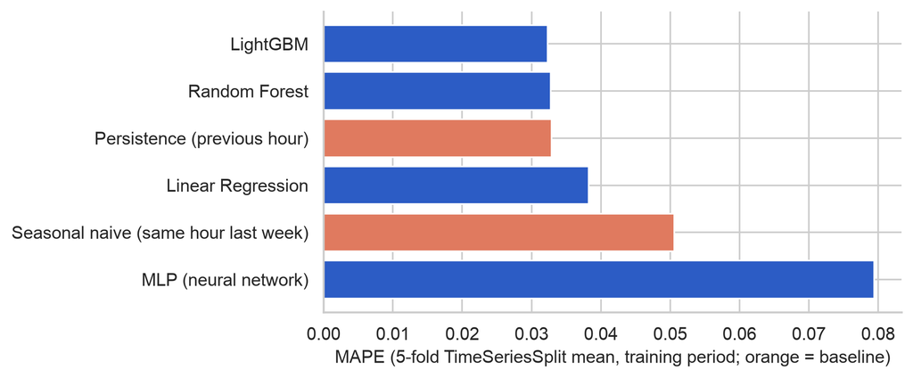

```python
cv_idx = cv_df.set_index("model")
is_baseline = cv_df["model"].isin(baselines.index)
fig, ax = plt.subplots(figsize=(6.5, 3.4))
ax.barh(cv_df["model"], cv_df["mape_mean"], color=[PALETTE[3] if b else PALETTE[0] for b in is_baseline])
ax.set_xlabel("MAPE (5-fold TimeSeriesSplit mean, training period; orange = baseline)")
plt.gca().invert_yaxis()
plt.show()
```

**LightGBM is the best learned model** (3.23% mean MAPE), ahead of Random Forest (3.28%) and Linear Regression (3.82%), and every model except the neural network clears the seasonal naive baseline (5.06%) comfortably. `MLP (neural network)` — a lightweight feedforward net (`sklearn.neural_network.MLPRegressor`, zero new dependencies) included specifically to test whether a neural approach earns its extra complexity — doesn’t: it finishes last (7.94%) with by far the largest fold-to-fold spread (`mape_std` 9.08%).

The more sobering comparison is with **persistence** (3.29%): at one hour ahead, the best model is only marginally better than repeating the previous hour on these folds.

## 6 Final chronological holdout

```python
holdout_rows = {}
for name, factory in model.MODEL_FACTORIES.items():
    pipe = model.train_pipeline(X_train_wo, y_train_wo, estimator=factory())
    holdout_rows[name] = model.regression_scores(y_test_wo, pipe.predict(X_test_wo))
    if name == "LightGBM":
        final_pipeline = pipe
holdout = pd.concat([pd.DataFrame(holdout_rows).T, baselines]).sort_values("mape")
test_preds = final_pipeline.predict(X_test_wo)
holdout.round(4)
```

|  | mae | rmse | mape |
| --- | --- | --- | --- |
| Persistence (previous hour) | 244.4572 | 313.8748 | 0.0394 |
| LightGBM | 239.2780 | 342.4446 | 0.0405 |
| MLP (neural network) | 258.8510 | 362.8145 | 0.0442 |
| Random Forest | 272.4969 | 396.5923 | 0.0466 |
| Linear Regression | 291.4789 | 402.7295 | 0.0485 |
| Seasonal naive (same hour last week) | 442.9998 | 645.5151 | 0.0744 |

On the untouched test period (February 2025 to March 2026), LightGBM is again the best of the four learned models (MAPE 4.05%, MAE 239 MW), and every model beats the seasonal naive baseline by a wide margin. But **it does not beat persistence one hour ahead**: repeating the previous hour scores 3.94% MAPE and 314 MW RMSE against LightGBM’s 4.05% and 342 MW, with LightGBM ahead only on MAE (239 vs 244 MW). For a 1-hour-ahead forecast, the honest summary is a tie with the simplest possible rule. Demand changes slowly from one hour to the next, and the models only see the previous hour diluted inside a 24-hour rolling mean.

One caveat cuts the other way. Interpolated hours (the outage gaps and the removed fabricated stretches) are straight lines, which are trivially easy for persistence and hard for the model, so scoring only the real, non-interpolated test hours is a useful check:

```python
filled = ~y_test_wo.index.isin(df[config.DATETIME_COL]) | y_test_wo.index.isin(flagged.index)
real = ~filled
pd.DataFrame({
    "LightGBM": model.regression_scores(y_test_wo[real], test_preds[real]),
    "Persistence (previous hour)": model.persistence_baseline(frame, y_test_wo[real]),
    "Seasonal naive (same hour last week)": model.naive_seasonal_baseline(X_test_wo[real], y_test_wo[real]),
}).T.round(4).assign(hours=int(real.sum()))
```

|  | mae | rmse | mape | hours |
| --- | --- | --- | --- | --- |
| LightGBM | 231.6011 | 325.9478 | 0.0395 | 9243 |
| Persistence (previous hour) | 247.1447 | 316.0689 | 0.0399 | 9243 |
| Seasonal naive (same hour last week) | 435.1844 | 633.8472 | 0.0735 | 9243 |

On the real hours alone LightGBM edges ahead on MAPE and MAE but stays behind on RMSE — the verdict for one hour ahead is still a tie.

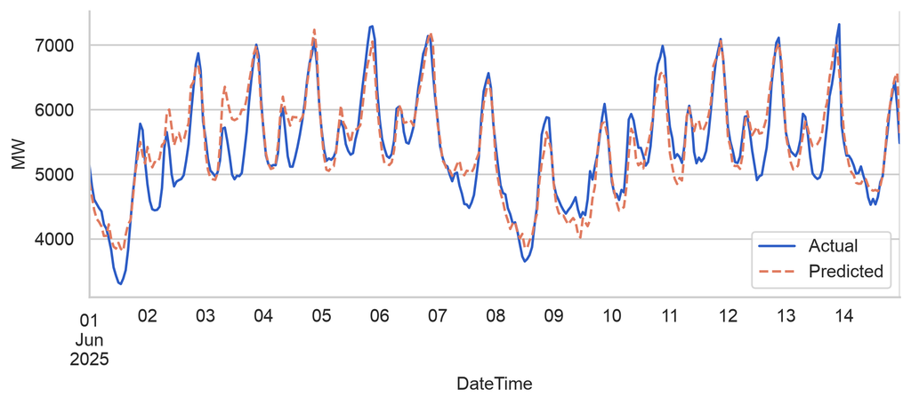

```python
fig, ax = plt.subplots(figsize=(9, 3.2))
sample_start, sample_end = "2025-06-01", "2025-06-14"
y_test_wo.loc[sample_start:sample_end].plot(ax=ax, label="Actual", color=PALETTE[0])
pd.Series(test_preds, index=y_test_wo.index).loc[sample_start:sample_end].plot(ax=ax, label="Predicted", linestyle="--", color=PALETTE[3])
ax.set_ylabel("MW")
ax.legend()
plt.show()
```

## 7 Forecasting 24 hours ahead: where the model earns its keep

A grid operator needs the next day, not just the next hour. For hour *t+2* and later the previous hour isn’t known yet, so persistence can only repeat the **last known** value, while the model forecasts recursively (`model.recursive_forecast`: predict one hour, feed the prediction back in, up to 24 hours; within that cap `lag_24h`, `lag_168h` and all generation-mix features stay real data). For a fair comparison, the LightGBM pipeline below is trained **only on the training period** (never the saved all-data model), and forecasts 24 hours from an anchor every 23 hours across the whole test period (so anchors cycle through every hour of the day), scored per step ahead against “repeat the last known value” and “same hour last week”.

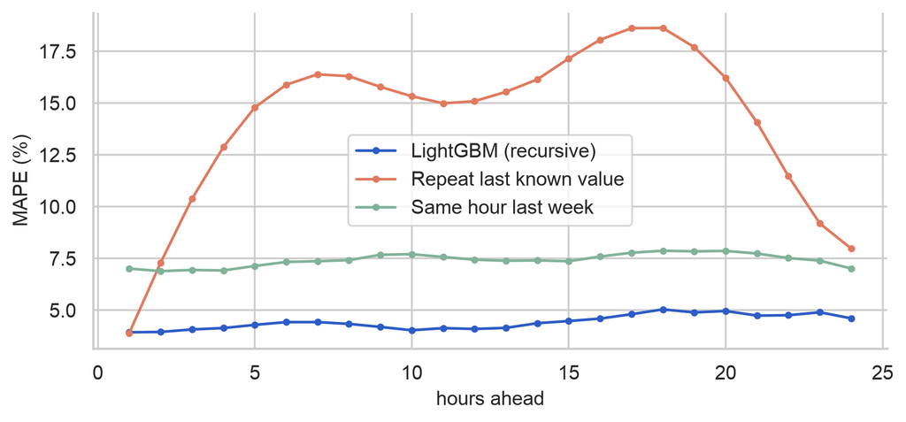

```
410 anchors, 410 scored at every step
```

|  | 1 h | 2-6 h | 7-12 h | 13-18 h | 19-24 h | all 24 h |
| --- | --- | --- | --- | --- | --- | --- |
| LightGBM (recursive) | 3.94 | 4.18 | 4.21 | 4.58 | 4.82 | 4.44 |
| Repeat last known value | 3.90 | 12.25 | 15.65 | 17.36 | 12.77 | 14.16 |
| Same hour last week | 7.01 | 7.05 | 7.53 | 7.57 | 7.57 | 7.43 |

```python
from energy_demand_forecasting import config

candidates = y_test_wo.index[: -(config.MAX_FORECAST_HORIZON_HOURS + 1)]
anchors = list(candidates[::23])
horizon = model.forecast_error_by_horizon(final_pipeline, frame, anchors).set_index("steps_ahead")
horizon_labels = {"mape": "LightGBM (recursive)", "persistence_mape": "Repeat last known value",
                  "seasonal_naive_mape": "Same hour last week"}

fig, ax = plt.subplots(figsize=(8, 3.4))
for col, color in zip(horizon_labels, [PALETTE[0], PALETTE[3], PALETTE[4]]):
    (horizon[col] * 100).plot(ax=ax, marker=".", color=color, label=horizon_labels[col])
ax.set_xlabel("hours ahead")
ax.set_ylabel("MAPE (%)")
ax.legend()
plt.show()

blocks = {"1 h": slice(1, 1), "2-6 h": slice(2, 6), "7-12 h": slice(7, 12),
          "13-18 h": slice(13, 18), "19-24 h": slice(19, 24), "all 24 h": slice(1, 24)}
horizon_summary = pd.DataFrame({k: horizon.loc[v, list(horizon_labels)].mean() for k, v in blocks.items()}).rename(index=horizon_labels)
print(f"{len(anchors)} anchors, {horizon['n_anchors'].iloc[0]} scored at every step")
(horizon_summary * 100).round(2)
```

This is where the model is worth having. At step 1 it ties persistence (3.94% vs 3.90%), as in the holdout above. From step 2 on, repeating the last known value falls apart — it cannot follow the daily cycle, peaking at 18.6% and averaging 14.2% over the 24 hours — and “same hour last week” stays around 7.4%. The recursive forecast degrades only gently, from 3.9% one hour ahead to 4.8% on average for 19-24 hours ahead, and averages 4.44% over the full day. Over a 24-hour horizon, the better of the two baselines (same hour last week) makes about 1.7 times the model’s error.

## 8 Model interpretability

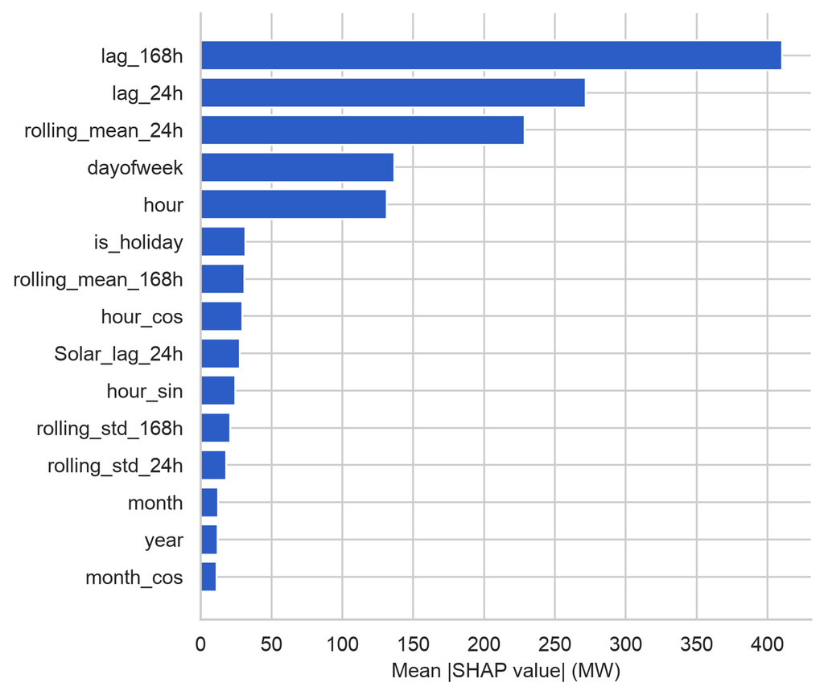

```python
from energy_demand_forecasting.interpretability import compute_shap_values, top_shap_features

explanation, X_transformed = compute_shap_values(final_pipeline, X_without, max_samples=500)
top = top_shap_features(explanation, top_n=15).sort_values("mean_abs_shap")

fig, ax = plt.subplots(figsize=(6, 6))
ax.barh(top["feature"], top["mean_abs_shap"], color=PALETTE[0])
ax.set_xlabel("Mean |SHAP value| (MW)")
plt.show()
```

## 9 Discussion: what this project can’t do, and what a Vietnam version would need

- **This dataset is live and not fully reproducible.** Every number above reflects one snapshot; a fresh download will add rows without changing historical ones, but the exact row counts and test-set contents quoted here are tied to this specific download.
- **The 2024-2025 outage gaps are patched with a rough approximation.** An 83-hour linear interpolation can’t recover real demand swings for that stretch — evaluation numbers touching that period are measured on partly reconstructed, not fully real, data. The same goes for the fabricated 2025-2026 stretches the outlier rule removes: they are interpolated too, and milder copies that trip neither trigger remain.
- **One hour ahead, the model is no better than persistence.** The value it adds is over a multi-hour horizon. A model aimed squarely at the next hour would at least need the previous hour as its own feature (`lag_1h`), at the cost of faster error compounding when used recursively.
- **No weather data** — the sharp winter-heating seasonality is only seen through the calendar, never an actual temperature reading.
- **Different climate and market structure than Vietnam.** Romania’s winter-heating-dominant demand shape is close to the opposite of Vietnam’s likely summer-cooling-dominant shape. The *methodology* transfers directly; the specific calendar, climate-driven seasonality, and holiday structure would not.
- **The renewable-share angle connects most directly to Vietnam’s own situation**: Vietnam’s grid is going through its own fast solar and wind buildout, with well-documented grid-stability and curtailment challenges. A genuine Vietnam version of this analysis would need Vietnam’s own hourly generation-mix data, which I could not find in public, granular form.

## 10 Conclusion

Switching from a frozen US demand series to this live Romanian consumption-and-production dataset paid off in ways beyond just having more columns: it forced a genuine leakage-trap decision (lagging every generation-mix feature), surfaced a real, previously-unseen data-quality problems (multi-hour 2024-2025 outage gaps, structurally different from the DST issue, and fabricated scaled-copy readings that had produced the dataset’s apparent 12,000 MW “peak”), and gave two honest negative/surprising results worth reporting on their own terms — the seasonal-decomposition feature added nothing once properly leakage-checked, and yesterday’s solar output ranks surprisingly high in the final model’s own explanation of itself, for reasons I can guess at but haven’t proven. LightGBM’s win over both classical regression and a neural-network baseline held up on this dataset exactly as it did on the original US version — a second, independent piece of evidence that the highest common instinct (“try a neural net”) isn’t automatically the right one for a tabular, well-feature-engineered forecasting problem like this. The most important correction, though, came from adding the right baseline: one hour ahead, simply repeating the previous hour is as good as any model here, so the project’s real claim is a narrower one — the model’s value is in forecasting a whole day ahead, where it keeps its error at roughly 4-5% while the no-model alternatives sit at 7% or far worse.